# RDD Script

Jan Nimczik

# Empricial Analysis

Let’s get some data on mortality and age. For ages 19 to 23 we have data on deaths per 100,000 persons per year by month of age and differentiated by different causes of death.

```r
library("tidyverse")
library("haven")
library("rlang")
library("broom")
library("lmtest")
library("sandwich")

mlda <- read.csv("mlda_data.csv")
summary(mlda)
```

[output not shown]

# Data

- `agecell` Average age in the particular age cell
- `all` total number of deaths in age cell
- `internal` number of deaths with internal causes
- `external` number of deaths with external causes
- `mva` number of death due to motor vehicle accidents

# Data Preparation

- Define a variable `age` that is normalized to 0 at the cutoff
- Add a variable `age = age^2`
- Add an indicator variable for individuals over 21 years of age, `over21`.

```r
mlda <- mutate(mlda,
               age = agecell - 21,
               age2 = age^2,
               over21 = as.integer(agecell >= 21))
```

## Linear Model

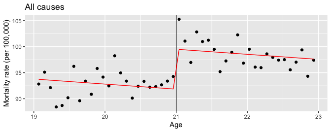

```r
fit <- data.frame(all_fit = predict(lm(all~agecell+over21, data=mlda)), agecell = mlda$agecell)

ggplot(mlda, aes(x=agecell, y=all)) + geom_point()+
  geom_vline(xintercept = 21) +
  geom_line(data=fit, aes(y=all_fit, x = agecell), color = 'red') +
  labs(title = "All causes", y = "Mortality rate (per 100,000)",
       x = "Age")
```

```r
model1 <- lm(all ~ age  + over21, data = mlda )
summary(model1)
```

```
Call:
lm(formula = all ~ age + over21, data = mlda)

Residuals:
    Min      1Q  Median      3Q     Max
-5.0559 -1.8483  0.1149  1.4909  5.8043

Coefficients:
            Estimate Std. Error t value Pr(>|t|)
(Intercept)  91.8414     0.8050 114.083  < 2e-16 ***
age          -0.9747     0.6325  -1.541     0.13
over21        7.6627     1.4403   5.320 3.15e-06 ***
---
Signif. codes:  0 ‘***’ 0.001 ‘**’ 0.01 ‘*’ 0.05 ‘.’ 0.1 ‘ ’ 1

Residual standard error: 2.493 on 45 degrees of freedom
Multiple R-squared:  0.5946,    Adjusted R-squared:  0.5765
F-statistic: 32.99 on 2 and 45 DF,  p-value: 1.508e-09
```

## Polynomial model

[figure not shown]

```r
ggplot(mlda, aes(x=agecell, y=all)) + geom_point()+
  geom_smooth(mapping = aes(group = over21), se = FALSE, method = "lm",
              formula = y ~ poly(x, 2)) +
  geom_smooth(mapping = aes(group = over21), se = FALSE, method = "lm",
              formula = y ~ poly(x, 8), color = "black")+
  geom_vline(xintercept = 21) +
  labs(title= "Motor Vehicle Accidents", y = "Mortality rate (per 100,000)"
       , x = "Age")
```

```r
model2 <- lm(all ~ age*over21 + age2*over21 , data = mlda)
summary(model2)
```

```
Call:
lm(formula = all ~ age * over21 + age2 * over21, data = mlda)

Residuals:
    Min      1Q  Median      3Q     Max
-4.3343 -1.3946  0.1849  1.2848  5.0817

Coefficients:
            Estimate Std. Error t value Pr(>|t|)
(Intercept)  93.0729     1.4038  66.301  < 2e-16 ***
age          -0.8306     3.2901  -0.252    0.802
over21        9.5478     1.9853   4.809 1.97e-05 ***
age2         -0.8403     1.6153  -0.520    0.606
age:over21   -6.0170     4.6529  -1.293    0.203
over21:age2   2.9042     2.2843   1.271    0.211
---
Signif. codes:  0 ‘***’ 0.001 ‘**’ 0.01 ‘*’ 0.05 ‘.’ 0.1 ‘ ’ 1

Residual standard error: 2.285 on 42 degrees of freedom
Multiple R-squared:  0.6821,    Adjusted R-squared:  0.6442
F-statistic: 18.02 on 5 and 42 DF,  p-value: 1.624e-09
```

## Extra Analyses

The Regression Discontinuity Design has the advantage that we can show nice and intuitive graphs. Also, we can use some extra analyses to make our causal effect more plausible.

### Differentiate by causes of death

Our data allows to separate between different causes of death. Let’s look at two different causes:

- `mva` Motor vehicle accindents
- `internal` Internal causes

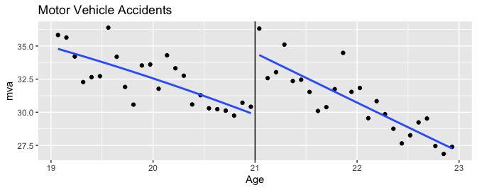

```r
ggplot(mlda, aes(x=agecell, y=mva)) + geom_point() +
  geom_smooth(mapping = aes(group = over21), se = FALSE, method = "lm",
              formula = y ~ poly(x, 2)) +
  geom_vline(xintercept = 21) +
  labs(title= "Motor Vehicle Accidents", y = "mva"
       , x = "Age")
```

[figure not shown]

```r
ggplot(mlda, aes(x=agecell, y=internal)) + geom_point() +
  geom_smooth(mapping = aes(group = over21), se = FALSE, method = "lm",
              formula = y ~ poly(x, 1)) +
  geom_vline(xintercept = 21) +
  labs(title= "Motor Vehicle Accidents", y = "internal"
       , x = "Age")
```

```r
mva_causes <- lm(mva ~ age*over21 + age2*over21 , data = mlda)
summary(mva_causes)
```

```
Call:
lm(formula = mva ~ age * over21 + age2 * over21, data = mlda)

Residuals:
    Min      1Q  Median      3Q     Max
-2.4646 -0.7761 -0.2646  0.8613  3.2418

Coefficients:
            Estimate Std. Error t value Pr(>|t|)
(Intercept)  29.8090     0.8166  36.505  < 2e-16 ***
age          -2.9330     1.9138  -1.533 0.132877
over21        4.6629     1.1548   4.038 0.000224 ***
age2         -0.1852     0.9396  -0.197 0.844662
age:over21   -0.8231     2.7065  -0.304 0.762527
over21:age2   0.1985     1.3288   0.149 0.881980
---
Signif. codes:  0 ‘***’ 0.001 ‘**’ 0.01 ‘*’ 0.05 ‘.’ 0.1 ‘ ’ 1

Residual standard error: 1.329 on 42 degrees of freedom
Multiple R-squared:  0.7224,    Adjusted R-squared:  0.6894
F-statistic: 21.86 on 5 and 42 DF,  p-value: 1.017e-10
```